# Data Science Log #3

Rrustem Sallauka  
2026-02-24

## Pixar Films

For small datasets like these adding them to git is not a problem.

```r
library(tidyverse)
pixar_films <- readr::read_csv('https://raw.githubusercontent.com/rfordatascience/tidytuesday/main/data/2025/2025-03-11/pixar_films.csv')
pixar_films <- pixar_films %>% drop_na(film)
pixar_films$film_rating <- factor(pixar_films$film_rating, exclude = NULL)
```

The possible values are G and PG. The rating based on Motion Picture Association (MPA) film rating system. G: General Audiences PG: Parental Guidance Suggested

film_rating is a categorical variable,because it has a fixed and known set of possible values, which when we transform can help us analising and vizualising

```
Inspect the film titles manually. Which films form a film series? A
film series can be identified by a common word in the titles of the
films, often in conjunction with a number in the title,
e.g. "Despicable Me" and "Despicable Me 2". Create a dataframe which
displays a list of the different series with the titles of the films
and how many films belong to the series. Output the dataframe.
```

```r
film_series <- pixar_films %>%
  filter(str_detect(film, "Cars") |
         str_detect(film, "Toy Story") |
         str_detect(film, "Incredibles") |
         str_detect(film, "Finding")|
         str_detect(film, "Monsters")) %>% mutate(
           series = case_when(
         str_detect(film, "Cars") ~ "Cars" ,
         str_detect(film, "Toy Story") ~ "Toy Story",
         str_detect(film, "Incredibles") ~ "Incredibles",
         str_detect(film, "Finding") ~ "Finding",
         str_detect(film, "Monsters") ~ "Monsters")
         )
film_series <- film_series %>% group_by(series) %>% mutate(count = n())

film_series
```

```
# A tibble: 13 × 7
# Groups:   series [5]
   number film          release_date run_time film_rating series count
    <dbl> <chr>         <date>          <dbl> <fct>       <chr>  <int>
 1      1 Toy Story     1995-11-22         81 G           Toy S…     4
 2      3 Toy Story 2   1999-11-24         92 G           Toy S…     4
 3      4 Monsters, In… 2001-11-02         92 G           Monst…     2
 4      5 Finding Nemo  2003-05-30        100 G           Findi…     2
 5      6 The Incredib… 2004-11-05        115 PG          Incre…     2
 6      7 Cars          2006-06-09        117 G           Cars       3
 7     11 Toy Story 3   2010-06-18        103 G           Toy S…     4
 8     12 Cars 2        2011-06-24        106 G           Cars       3
 9     14 Monsters Uni… 2013-06-21        104 G           Monst…     2
10     17 Finding Dory  2016-06-17         97 PG          Findi…     2
11     18 Cars 3        2017-06-16        102 G           Cars       3
12     20 Incredibles 2 2018-06-15        118 PG          Incre…     2
13     21 Toy Story 4   2019-06-21        100 G           Toy S…     4
```

```
Load the `public_response` dataframe into R. Convert the
`cinema_score` variable into a factor while ensuring the factor
levels are defined in ascending order, from the lowest to the
highest score. Combine `public_response` with the `pixar_films`
dataset using an appropriate merge variable.
```

```r
public_response <- readr::read_csv('https://raw.githubusercontent.com/rfordatascience/tidytuesday/main/data/2025/2025-03-11/public_response.csv')

public_response$cinema_score <- factor(public_response$cinema_score, levels = c("A-","A","A+"), exclude = NULL, ordered = TRUE)
public_pixar <- merge(film_series, public_response, by = "film")
```

```
Choose one of the variables representing the public response and
create a bar plot for the films belonging to a series. Here are the
details of the plot:

-   The film series are represented on the x-axis.
-   Your chosen public response variable is displayed on the y-axis.
-   Each film in the series is represented as a separate bar. Bars
    are grouped by film under their respective series on the x-axis.
    Order the bars within a series according to the release date of
    the films.
-   A title and axis labels for context.

What do you notice when comparing the scores of the films in a
series? Do you see any patterns?
```

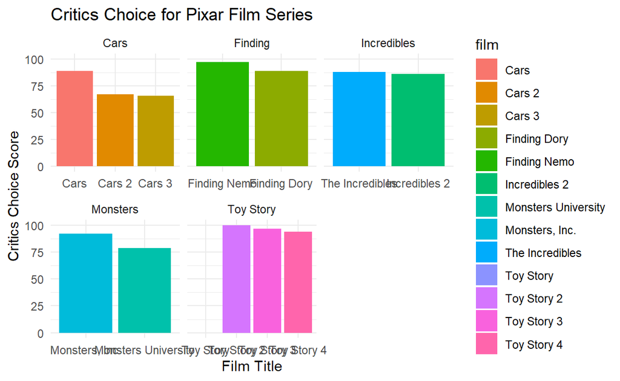

```r
ggplot(public_pixar <- public_pixar %>% mutate(release_date = as.Date(release_date)),
  aes(x = reorder(film, release_date), y = critics_choice, fill = film)) +
  geom_col(position = "dodge") +
  facet_wrap(~series, scales = "free_x") +
  labs(
    title = "Critics Choice for Pixar Film Series",
    x = "Film Title",
    y = "Critics Choice Score"
  ) +
  theme_minimal()
```

## Open Analysis

```r
energy_prices <- read_csv("data/Energy Prices - BP Statistics (2016).csv")
```

Put the name / title of the dataset and a link to it below.

- Dataset Name: Energy Prices - BP Statistics (2016)
- Link: https://github.com/owid/owid-datasets/tree/master/datasets/Energy%20Prices%20-%20BP%20Statistics%20(2016)#energy-prices---bp-statistics-2016

  Come up with a (research) question you want to answer with the data and briefly explain why you believe this is an interesting question within one sentence. It should be a question that can be answered with the dataset and using R. How have energy prices changed over time?

  Use R to answer your chosen question. Please limit your analysis to the functions and techniques we have covered so far in the course. You are **not expected** to use advanced statistical models or external packages which haven’t been introduced.

```r
energy_prices <- energy_prices %>% pivot_longer(cols = -c(Entity,Year),names_to = "source", values_to = "price")

energy_prices
```

```
# A tibble: 87 × 4
   Entity  Year source                             price
   <chr>  <dbl> <chr>                              <dbl>
 1 World   1987 Oil (BP Statistics (2016))          98.1
 2 World   1987 Natural Gas (BP Statistics (2016))  NA
 3 World   1987 Coal (BP Statistics (2016))         87.0
 4 World   1988 Oil (BP Statistics (2016))          76.2
 5 World   1988 Natural Gas (BP Statistics (2016))  NA
 6 World   1988 Coal (BP Statistics (2016))        111.
 7 World   1989 Oil (BP Statistics (2016))          88.8
 8 World   1989 Natural Gas (BP Statistics (2016))  40.1
 9 World   1989 Coal (BP Statistics (2016))        117.
10 World   1990 Oil (BP Statistics (2016))         110.
# ℹ 77 more rows
```

```
Create a meaningful plot / figure with the dataset. Make sure to
provide a figure caption (via the chunk options / Rmarkdown) and
correctly label the figure.
```

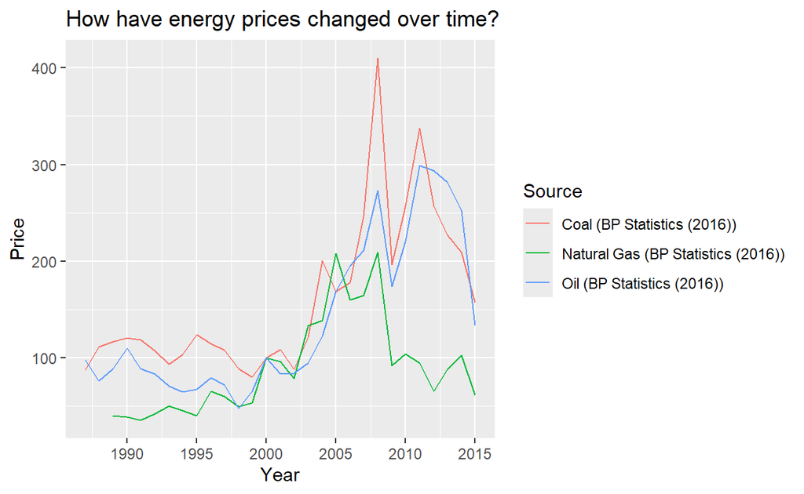

```r
ggplot(
  energy_prices,
  aes(
    x = Year,
    y = price,
    colour = source
  )
) + geom_line() + labs(
  title = "How have energy prices changed over time?",
  x = "Year",
  y = "Price",
  color = "Source"
)
```